## Setup

### Load packages

```r
library(ggplot2)
library(dplyr)
library(statsr)
library(BAS)
library(grid)
```

### Load data

```r
load("movies.Rdata")
```

## Part 1: Data

This data set includes 651 randomly sampled movies produced and released before 2016.

This is an observational experiment. Random sampling was used but Random assignment. So we can only analyse and make conclusions on generalisation, not causation.

## Part 2: Data manipulation

```r
movies <- movies %>%
          mutate(feature_film=as.factor(ifelse(title_type == 'Feature Film', 'yes', 'no'))) %>%
          mutate(drama=as.factor(ifelse(genre == 'Drama', 'yes', 'no'))) %>%
          mutate(mpaa_rating_R=as.factor(ifelse(mpaa_rating == 'R', 'yes', 'no'))) %>%
          mutate(oscar_season=as.factor(ifelse(thtr_rel_month %in% c(10:12), 'yes', 'no'))) %>%
          mutate(summer_season=as.factor(ifelse(thtr_rel_month %in% c(5:8), 'yes', 'no')))
```

## Part 3: Exploratory data analysis

We will conduct EDA of the relationship between audience_score and each variable (feature_film, drama, mpaa_rating_R, oscar_season, summer_season) one by one.

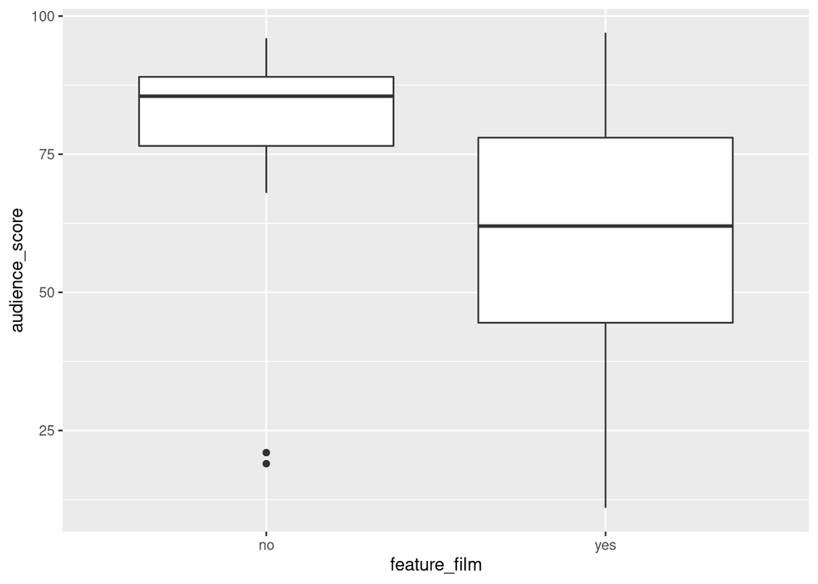

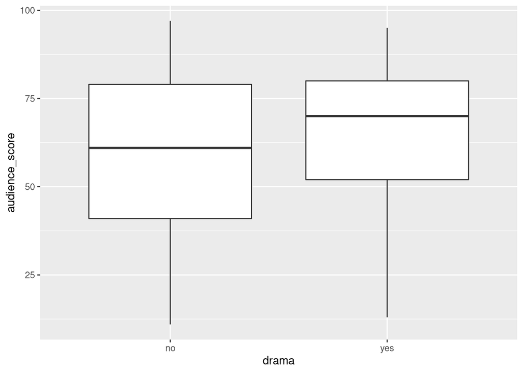

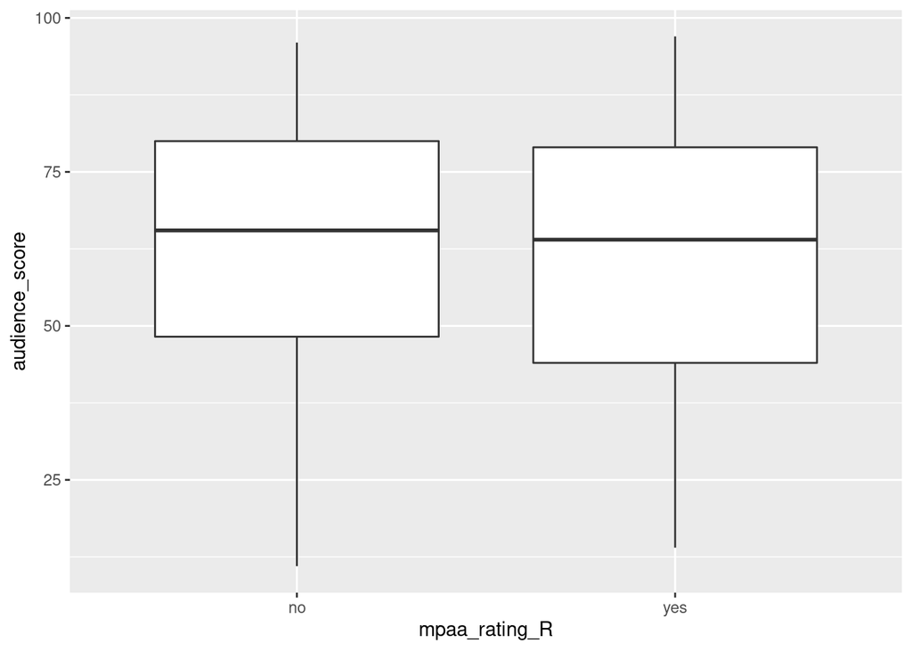

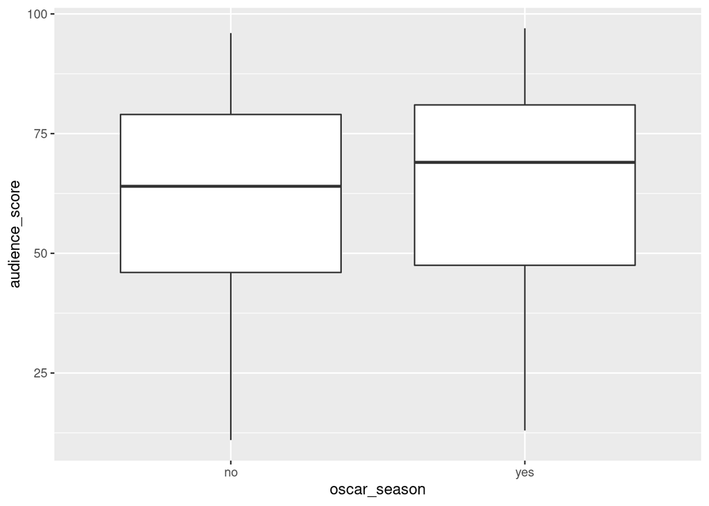

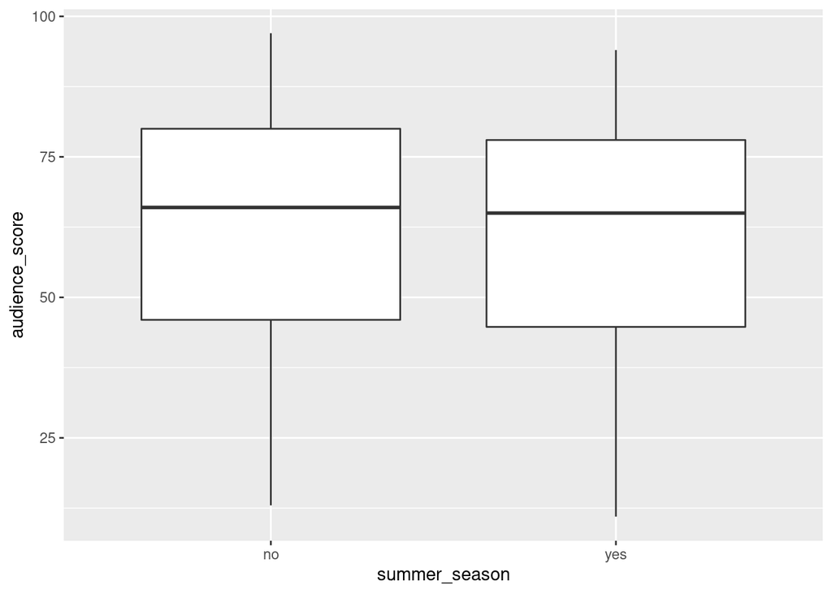

```r
relationship_1 <- ggplot(aes(x = feature_film, y = audience_score), data = movies) + geom_boxplot()
relationship_2 <- ggplot(aes(x = drama, y = audience_score), data=movies) + geom_boxplot()
relationship_3 <- ggplot(aes(x = mpaa_rating_R, y = audience_score), data = movies) + geom_boxplot()
relationship_4 <- ggplot(aes(x = oscar_season, y = audience_score), data = movies) + geom_boxplot()
relationship_5 <- ggplot(aes(x = summer_season, y = audience_score), data = movies) + geom_boxplot()

relationship_1; relationship_2; relationship_3; relationship_4; relationship_5
```

```r
summary(movies$audience_score)
```

```
##    Min. 1st Qu.  Median    Mean 3rd Qu.    Max.
##   11.00   46.00   65.00   62.36   80.00   97.00
```

The median of audience_score is 65 and the mean is 62. The biggest difference in the audience score is seen in the relationship between audience_score and feature_film.

## Part 4: Modeling

The number of features is not large so I would prefer to use Bayesian Regression to predict audience_score from all variables we have discussed so far.

```r
movies <- movies %>%
          mutate(log_audience_score = log2(audience_score))

movies <- na.omit(movies)

movies.BIC <- bas.lm(audience_score ~
                     imdb_rating + critics_score + runtime + imdb_num_votes + feature_film + drama + mpaa_rating_R + thtr_rel_year + oscar_season + summer_season + best_pic_nom +  best_pic_win + best_actor_win + best_actress_win + best_dir_win + top200_box,
                     data = movies,
                     prior = "BIC",
                     modelprior = uniform())

summary(movies.BIC)
```

```
##                     P(B != 0 | Y)    model 1       model 2       model 3
## Intercept              1.00000000     1.0000     1.0000000     1.0000000
## imdb_rating            1.00000000     1.0000     1.0000000     1.0000000
## critics_score          0.92015573     1.0000     1.0000000     1.0000000
## runtime                0.51399873     1.0000     0.0000000     0.0000000
## imdb_num_votes         0.06242230     0.0000     0.0000000     0.0000000
## feature_filmyes        0.05876309     0.0000     0.0000000     0.0000000
## dramayes               0.04508592     0.0000     0.0000000     0.0000000
## mpaa_rating_Ryes       0.16498090     0.0000     0.0000000     0.0000000
## thtr_rel_year          0.08088668     0.0000     0.0000000     0.0000000
## oscar_seasonyes        0.06525993     0.0000     0.0000000     0.0000000
## summer_seasonyes       0.07935408     0.0000     0.0000000     0.0000000
## best_pic_nomyes        0.13200908     0.0000     0.0000000     0.0000000
## best_pic_winyes        0.04076727     0.0000     0.0000000     0.0000000
## best_actor_winyes      0.11565473     0.0000     0.0000000     0.0000000
## best_actress_winyes    0.14770126     0.0000     0.0000000     1.0000000
## best_dir_winyes        0.06701259     0.0000     0.0000000     0.0000000
## top200_boxyes          0.04875994     0.0000     0.0000000     0.0000000
## BF                             NA     1.0000     0.8715404     0.2048238
## PostProbs                      NA     0.1558     0.1358000     0.0319000
## R2                             NA     0.7483     0.7455000     0.7470000
## dim                            NA     4.0000     3.0000000     4.0000000
## logmarg                        NA -3434.7520 -3434.8894481 -3436.3375603
##                           model 4       model 5
## Intercept               1.0000000     1.0000000
## imdb_rating             1.0000000     1.0000000
## critics_score           1.0000000     1.0000000
## runtime                 1.0000000     1.0000000
## imdb_num_votes          0.0000000     0.0000000
## feature_filmyes         0.0000000     0.0000000
## dramayes                0.0000000     0.0000000
## mpaa_rating_Ryes        1.0000000     0.0000000
## thtr_rel_year           0.0000000     0.0000000
## oscar_seasonyes         0.0000000     0.0000000
## summer_seasonyes        0.0000000     0.0000000
## best_pic_nomyes         0.0000000     1.0000000
## best_pic_winyes         0.0000000     0.0000000
## best_actor_winyes       0.0000000     0.0000000
## best_actress_winyes     0.0000000     0.0000000
## best_dir_winyes         0.0000000     0.0000000
## top200_boxyes           0.0000000     0.0000000
## BF                      0.2039916     0.1851908
## PostProbs               0.0318000     0.0289000
## R2                      0.7496000     0.7495000
## dim                     5.0000000     5.0000000
## logmarg             -3436.3416317 -3436.4383237
```

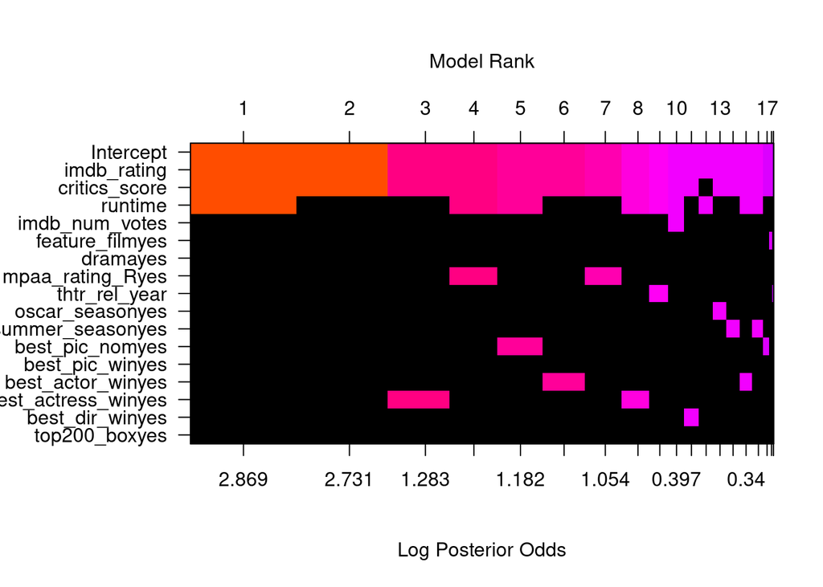

```r
image(movies.BIC, rotate=F)
```

Please note that I could not make the below code run both on my local device and RStudio Cloud (I think it takes too much resources) but I believe that eventually we will still see that critics_score and imdb_rating have the lowest zero coefficient probability. This affects the code in section 5 (Prediction) too.

Please kindly understand this.

```r
# models <-bas.lm(audience_score~.,data=movies, prior="ZS-null", modelprior = uniform(), method = "MCMC")

# plot(model, which=1, add.smooth=F)

#plot(model, which = 4, ask = F)
```

## Part 5: Prediction

I chose “Fantastic Beasts and Where to Find Them”

```r
fan_beasts <- data.frame(audience_score = 79,
                         feature_film = factor("yes", levels=c("yes", "no")),
                         drama = factor("no", levels = c("yes", "no")),
                         runtime = 132,
                         mpaa_rating_R = factor("no", levels = c("yes", "no")),
                         thtr_rel_year = 2016,
                         oscar_season = factor("yes", levels = c("yes", "no")),
                         summer_season = factor("no", levels = c("yes", "no")),
                         imdb_rating = 7.4,
                         imdb_num_votes = 320961,
                         critics_score = 74,
                         best_pic_nom = factor("no", levels = c("yes", "no")),
                         best_pic_win = factor("no", levels = c("yes", "no")),
                         best_actor_win = factor("no", levels = c("yes", "no")),
                         best_actress_win = factor("no", levels = c("yes", "no")),
                         best_dir_win = factor("no", levels = c("yes", "no")),
                         top200_box = factor("no", levels = c("yes", "no")))


# predicted_scores <- predict(models, newdata = fan_beasts, estimator = "BMA", se.fit=TRUE)

# margin <- qt(0.95, df = predicted_scores$se.bma.pred[1]) * mean(score_predic$se.bma.pred)

# results <- data.frame('title' = 'Fantastic Beast and where to find them', 'prediction' = sprintf('%2.1f', score_predic$Ybma), 'interval' = sprintf('%2.1f - %2.1f', score_predic$Ybma - margin,  score_predic$Ybma + margin), 'actual' = 79)

# results
```

## Part 6: Conclusion

Significant predictors are imdb rating and critics score.